# Buggin’ Around Campus

G. Tomboc

2025-10-28

[figure not shown]

The Volkswagen Beetle — only the best car to get if you want to spend tons of money on maintenance issues. Hey! At least they’re cute though, right? For my project I decided to look at how many bugs were parked on campus. I wandered around campus hoping to find any bug. To my surprise, I quickly discovered that a VW bug was likely an endangered species… :(

So, I decided to expand my study area to be NEAR campus! (It was still extremely difficult to find bugs, but I did the best with what I was given..)

Anyways…

## Fix the data

```r
#read in csv file
bug_points <- read.csv("buggin.around.csv")

bug_points <- bug_points %>%
  mutate(
    popup_html = paste0(
      "<div style='text-align:center;'>",
      "<b>Color:</b>", Color, "<br>",
      "<a href='", Photo, "' target='_blank'>
      <img src='", Photo, "'style='width:300px; height:auto; border-radius:12px;'>
      </a>",
      "</div>"
    )
  )

#make color pallete
car_colors <- c("Black" = "black",
                "White" = "ivory",
                "Grey" = "grey5",
                "Orange" = "orange",
                "Red" = "red",
                "Yellow" = "yellow")
```

## Google Links

[**Buggin Around Campus Form**](https://docs.google.com/forms/d/1wDcEgzPfVtCBT6dsdd4N59afkGrr9RXBBNPeGhAw3Bs/edit)

[**Buggin Around Campus Response Sheet**](https://docs.google.com/spreadsheets/d/1sad3_E7ut8TkJiTJGrG0IJB7tbnh36CBCsdoaeDeGyk/edit?gid=1931255490#gid=1931255490) (with responses of course!)

Let’s make this gorgina map now!

## Bug Map Code

```r
icon <- makeIcon(
  iconUrl = "ladybug.png",
  iconWidth = 35,
  iconHeight = 35
)

#make an interactive map
leaflet(data = bug_points) %>%
   addProviderTiles(providers$OpenStreetMap, group = "Satellite") %>%
   addProviderTiles(providers$Esri.WorldImagery, group = "Road Map") %>%
  addMarkers(
    lng = ~Longitude,
    lat = ~Latitude,
    icon = ~icon,
    popup = ~popup_html
)%>%
  addLayersControl(
    baseGroups = c("Road Map", "Satellite"),
    options = layersControlOptions(collapsed = FALSE)
)%>%
    addScaleBar(position = "bottomleft") %>%
    addLayersControl(
    baseGroups = c("Road Map", "Satellite"),
    options = layersControlOptions(collapsed = FALSE)
)
```

[interactive chart not shown]

YAY!!!! I don’t even want to talk about how difficult it was to autopopulate these images. It was awful.

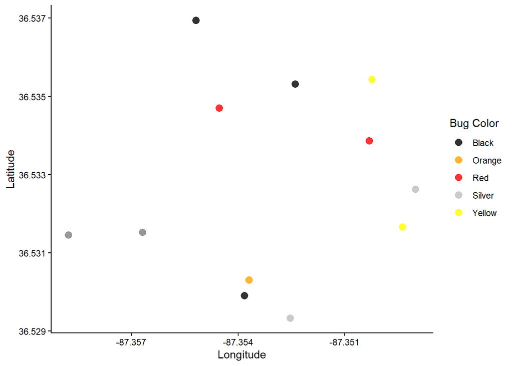

```r
ggplot(bug_points, aes(x = Longitude, y = Latitude, color = Color )) +
  geom_point(size = 3, alpha = 0.8) +
  scale_color_manual(values = c(
    "Red" = "red",
    "Yellow" = "yellow",
    "Orange" = "orange",
    "Silver" = "grey",
    "Black" = "black"
  )) +
  theme_classic() +
  labs(
    x = "Longitude",
    y = "Latitude",
    color = "Bug Color"
  )
```

```r
anova <- aov(Latitude ~ Color, bug_points)
summary(anova)
```

```
##             Df    Sum Sq   Mean Sq F value Pr(>F)
## Color        5 2.654e-05 5.308e-06   0.795   0.59
## Residuals    6 4.005e-05 6.674e-06
```

There is not a difference between where different colored bugs park across campus. (Obvi theres not enough data but this is just for fun #slay)